# 2 — Transforms and Forward Kinematics

Where is the foot? · SOC4180 Robot and AI

Hong Jeong

## One question, all week

> Given the joint angles, **where is the foot?**

That is *forward kinematics*. It sounds like bookkeeping, and it is — but nothing above it works without it.

- Week 3 inverts it to decide joint angles from a desired foot position
- Week 4 uses that to place footsteps
- Week 12 feeds it into a policy’s observations

Today you will work it out **on paper for a two-link leg**, then write it in code for all six joints, and check it against MuJoCo to the last decimal place.

## Why this is a question at all

A real robot does not know where its foot is. It knows **only what its sensors report**, and in each leg joint sits an encoder reporting one number: an angle.

```
what the left leg's six encoders report, in the crouch pose:
   hip_pitch_joint      -0.35 rad  =  -20.1 deg
   hip_roll_joint       +0.00 rad  =   +0.0 deg
   hip_yaw_joint        +0.00 rad  =   +0.0 deg
   knee_joint           +0.70 rad  =  +40.1 deg
   ankle_pitch_joint    -0.35 rad  =  -20.1 deg
   ankle_roll_joint     +0.00 rad  =   +0.0 deg
```

Six numbers. Nowhere among them is a position. **Forward kinematics is the function that turns those six angles into “the foot is here.”**

## The names you will meet today

Week 1 split the world in two: **`model`** is the robot (constants from the file, never change), **`data`** is this instant (changes every step). Every array below lives in one or the other, and there is a rule for telling which.

**An `x` in front means “computed, in world coordinates”.** No `x` means “declared in the MJCF, relative to the parent”.

| Declared — in `model` | Computed — in `data` |
| --- | --- |
| `body_pos[b]`, `body_quat[b]` — link’s fixed offset from its **parent** | `xpos[b]`, `xmat[b]` — where body `b` **actually is**, in world |
| `site_pos[s]` — a marker’s fixed offset inside its body | `site_xpos[s]`, `site_xmat[s]` — where that marker actually is |
| `jnt_pos[j]`, `jnt_axis[j]` — where the joint sits, and what it turns about | `qpos` — the current angles |

```
model.body_pos [declared, from its parent] : [-0.0783  0.0021 -0.1773]
data .xpos     [computed, in world]        : [-0.      0.1186  0.3507]

model.site_pos [declared, inside its body] : [0. 0. 0.]
data .site_xpos[computed, in world]        : [-0.      0.1185  0.0331]
data .site_xmat[computed, 3x3 flattened]   : [1. 0. 0. 0. 1. 0. 0. 0. 1.]
```

**`mujoco.mj_forward(model, data)` is what connects the columns.** It reads `data.qpos` and fills in every `x` quantity. In other words: *MuJoCo already has forward kinematics, and `mj_forward` is it.* Today you write your own and check it against MuJoCo’s, which is why we can demand agreement to the last decimal.

(Functions beginning `mju_` are small maths utilities — quaternion and matrix conversions. Each is introduced where it is first needed.)

## …and the helpers that do the index bookkeeping

MuJoCo addresses everything by integer id, so `soc4180.kinematics` (imported as `kin`) carries the lookups for the left and right legs. Four you will see all day:

```
kin.LEG_JOINTS            : ('hip_pitch_joint', 'hip_roll_joint', 'hip_yaw_joint', 'knee_joint', 'ankle_pitch_joint', 'ankle_roll_joint')
kin.leg_chain(model,'left'): [2, 3, 4, 5, 6, 7]  <- body ids, hip to foot
kin.foot_site_id(...)      : 1  <- the site id

kin.leg_qpos_indices(...)  : [ 7  8  9 10 11 12]  <- slots in qpos (positions)
kin.leg_dof_indices(...)   : [ 6  7  8  9 10 11]  <- slots in qvel (velocities)
```

**Look at those last two: `7..12` against `6..11`.** The same six joints have different addresses in position space and velocity space, off by one — because the floating base spends **7** numbers on position and only **6** on velocity. That is the `nq` versus `nv` gap of Week 1, showing up as an indexing hazard you will hit if you mix them.

`soc4180.keyframe_data(model, "stand")` gives a fresh `data` already posed at a named keyframe — a shortcut for `MjData` plus a copy of `key_qpos`.

## What those six numbers do

Only the **left** leg’s six angles change below. The right leg is untouched, so you can use it as a ruler:

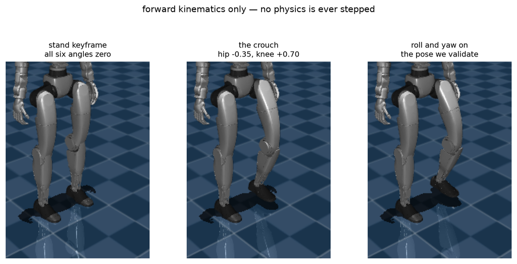

Nothing here is *simulated*. Each pose is placed and drawn. Kinematics is a statement about **geometry**, not about balance — a pose can be perfectly valid and still be one the robot could never hold.

## Frames: a position needs a “relative to what”

Ask where your phone is. *On the desk* — but the desk is in a room, in a moving building, on a spinning planet. Every answer is relative to something you did not say out loud.

Robotics makes it explicit. A **frame** is an origin plus three axes, and every position is measured in some frame:

- **world** — fixed to the ground, never moves
- **pelvis** — the robot’s own body frame, which moves with the robot
- one frame per link — thigh, shin, foot, each fixed to its own piece of metal

“The foot is at $(0, 0.12, 0.03)$” is only true in a *stated* frame. Most robotics bugs are one number used in the wrong one, and they do not look like bugs — they look like a robot that is slightly, confusingly wrong.

## The same foot, three frames

One physical point. Three legitimate, different answers:

```
in the WORLD frame        : [-0.      0.1185  0.0331]
in the PELVIS frame       : [-0.      0.1185 -0.7569]
relative to the HIP joint : [-0.      0.0541 -0.6542]
```

The world answer says the foot is 3 cm above the floor. The pelvis answer says it is 76 cm below the hips. **Both are correct.** Neither is usable without its label.

## Three arrows, one foot

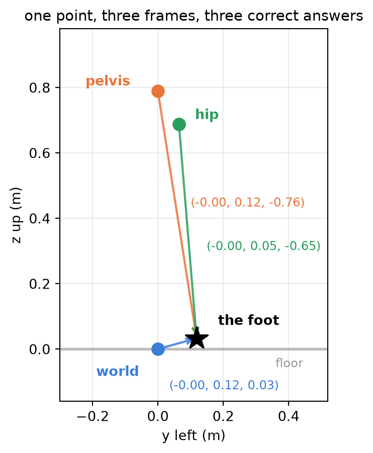

The arrows differ; the star does not move. **A frame is a question, not a place.**

## A transform is a rotation and a translation

To move a point from a child frame into its parent, do two things — turn it, then shift it:

$$\mathbf{p}_{\text{parent}} = \underbrace{R\,\mathbf{p}_{\text{child}}}_{\text{turn}} + \underbrace{\mathbf{t}}_{\text{shift}}$$

$R$ is a $3\times3$ **rotation matrix**; $\mathbf{t}$ is where the child’s origin sits in the parent. Chaining two of them — child to parent to grandparent — gives:

$$R_{ac} = R_{ab} R_{bc}, \qquad \mathbf{t}_{ac} = R_{ab}\mathbf{t}_{bc} + \mathbf{t}_{ab}$$

That second formula is the whole of forward kinematics. Everything else today is applying it six times in a row.

Note where $R_{ab}$ sits in the translation: **the parent’s rotation acts on the child’s offset.** Forget that and the leg swings from the wrong place.

## Rotating a point, in 2D, by hand

Start with one link in the $xz$ plane, hanging straight down from a pivot, tip at $(0, -L)$. Rotate it by $\theta$ about the $y$ axis:

$$\text{tip} = (-L\sin\theta,\; -L\cos\theta)$$

Check it with a calculator before trusting any code:

```
  theta =  0 deg -> tip at x = -0.0000,  z = -0.3400
  theta = 30 deg -> tip at x = -0.1700,  z = -0.2944
  theta = 90 deg -> tip at x = -0.3400,  z = -0.0000
```

## The same three angles, drawn

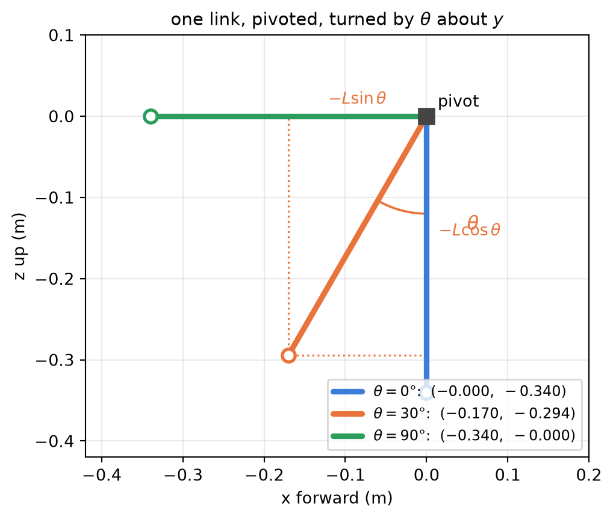

Read the signs off the picture. At $0°$ the tip hangs directly below. At $90°$ it has swung to horizontal at $x = -0.34$ — **backwards**. So a *positive* pitch angle swings the leg **back**, which is why the Week 4 crouch commands a hip pitch of $-0.35$: negative means knee forward.

## Order matters, and you can feel it

Put a book flat on the desk, cover up. Then:

1. Turn it $90°$ about the **vertical** axis, then tip it $90°$ **toward you**
2. Start over. Tip it $90°$ **toward you** first, then turn $90°$ about vertical

The book ends in two different orientations. This is not an illusion:

```
  start with the point       [1. 0. 0.]
  about z, then x        ->  [0. 0. 1.]
  about x, then z        ->  [0. 1. 0.]
  the answers are 1.414 apart
```

Same point, same two rotations, **a different axis entirely**. Matrix multiplication does not commute, and neither does turning things in space.

## The book, both ways

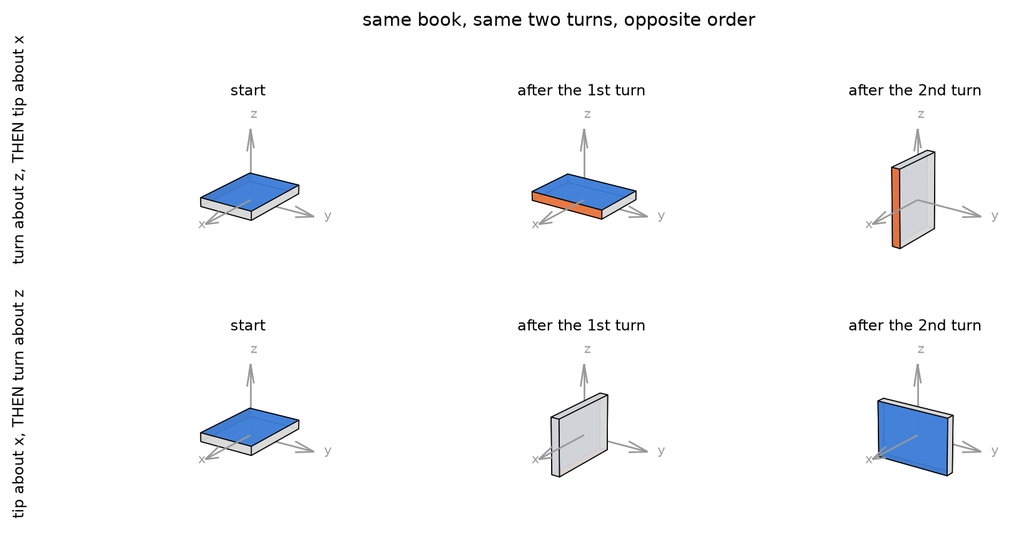

Follow the **blue cover** and the **orange spine**. Both rows start identically and end differently.

**Consequence:** “roll 10°, pitch 20°, yaw 5°” is meaningless until you say in which order. That is why we compose matrices down the chain instead.

## Two links on paper: the leg you are about to code

Chain the 2D result twice. Hip at height $z_h$, thigh $L_1$, shin $L_2$, hip angle $\theta_1$, knee angle $\theta_2$:

$$\text{knee} = \big(-L_1\sin\theta_1,\;\; z_h - L_1\cos\theta_1\big)$$
$$\text{ankle} = \big(\text{knee}_x - L_2\sin(\theta_1{+}\theta_2),\;\; \text{knee}_z - L_2\cos(\theta_1{+}\theta_2)\big)$$

The angles **add**, because the knee angle is measured relative to the thigh and the thigh has already turned by $\theta_1$.

Now measure $L_1$ and $L_2$ from the real robot — **between joint anchors**, not from any single body offset:

```
  hip -> knee   : [-0.      0.0541 -0.3366]   true length 0.3409 m,  in-plane L1 = 0.3366 m
  knee -> ankle : [ 0.e+00 -1.e-04 -3.e-01]   true length 0.3000 m,  in-plane L2 = 0.3000 m
  ankle -> foot site : 0.0176 m   (the site is NOT the sole -- see below)
```

Look at the thigh: it is **not** straight down. It splays 5.4 cm sideways, so its true length 0.3409 m is not the number a flat picture needs — 0.3366 m is.

## The leg, as the formula sees it

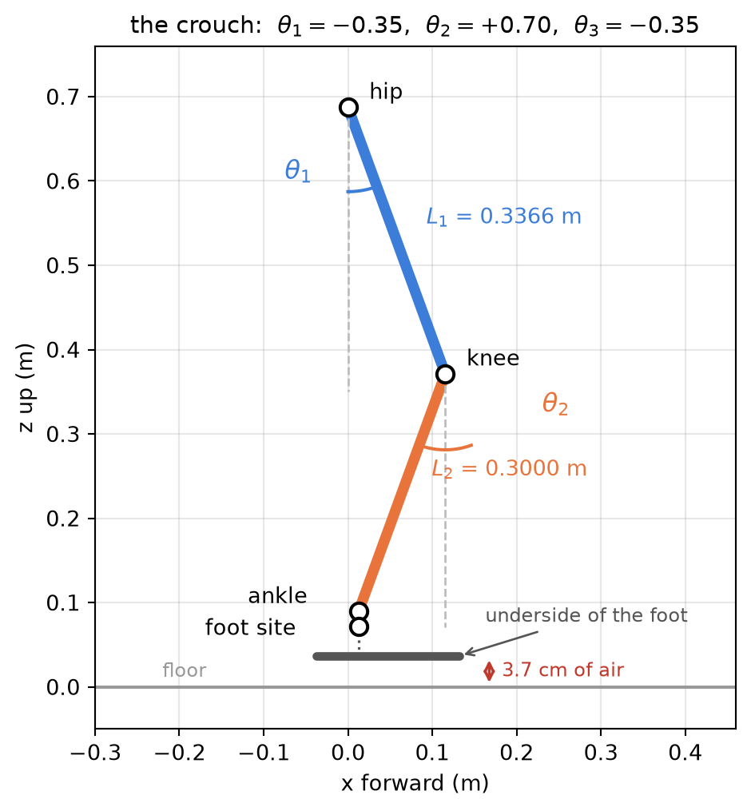

Each dashed line is where the link **would** point at zero angle, so each arc is literally the joint’s angle. The knee angle is measured **from the thigh**, not from vertical — which is why the two add in the formula.

## Two things that figure is telling you

**The site we call “the foot” is not the bottom of the foot.** `left_foot` is a site at the ankle-roll link’s *origin*, 3.5 cm above the four contact spheres. Forward kinematics reports where that *frame* is; touching the ground is a separate question.

**And the foot is in the air.** The pelvis is pinned at standing height while the leg bends, so the foot rises 3.7 cm off the floor. That is not an error in the drawing — it is the point made three slides in: **kinematics places a pose; it does not settle a robot onto the ground.** A real crouch lowers the pelvis instead, which is exactly what the Week 4 walker does.

Two details worth noticing while you are here:

- The pitch angles sum to zero ($-0.35 + 0.70 - 0.35$), so the **foot stays level**. That is deliberate: a foot that lands tilted trips.
- The foot runs from $-0.05$ m (heel) to $+0.12$ m (toe) about the ankle. It is longer in front, which is why $+x$ is forward.

## Does the paper answer match the simulator?

Three angles in, one foot position out — pure arithmetic, no physics:

```
     hip, knee, ankle            paper (x, z)           mujoco (x, z)   error
            (0, 0, 0)  (+0.000000, +0.033136)  (-0.000002, +0.033136)   2.3e-06
  (-0.35, 0.7, -0.35)  (+0.012545, +0.071732)  (+0.012543, +0.071731)   2.2e-06
    (-0.4, 0.9, -0.5)  (-0.012756, +0.096433)  (-0.012758, +0.096432)   2.1e-06
     (0.3, 0.2, -0.1)  (-0.250141, +0.086282)  (-0.250143, +0.086283)   2.2e-06
```

**Two micrometres.** Your `sin` and `cos` predict a 29-degree-of-freedom simulator to about the width of a bacterium.

Not *zero*, though, and the gap is honest: the flat two-link picture is a **model** of the leg. At the zero pose MuJoCo puts the foot $2.3\,\mu$m *behind* the hip rather than exactly beneath it, because the G1’s own offsets do not quite cancel. Later in this lab we compose the real chain and the error drops to $10^{-16}$.

## What the two-link picture leaves out

It reached micrometres, so why not stop there? Because we cheated three times:

- **We held hip roll, hip yaw and ankle roll at zero.** Switch any of them on and the foot leaves the $xz$ plane, and flat trigonometry has nowhere to put it.
- **We computed a position, not a pose.** A foot also has an *orientation* — it has to land flat — and that is three more numbers.
- **We derived it for this leg.** Change the robot and you redo the algebra by hand.

**Six joints, six freedoms** — three of position, three of orientation. That match is not an accident of design: it is the minimum needed to put a foot *anywhere*, *any way up*. It is also why next week’s inverse problem is solvable at all.

So we need a method that handles all six, needs no algebra, and works for any robot. That method is: compose the transforms, one body at a time.

## Ways to write a rotation

**First, why bother?** Only the matrix multiplies a vector. So if the matrix does all the work, why does anyone use the other three?

**Because a rotation is three numbers’ worth of information, and the matrix spends nine.** The other three forms are compressions of it:

| Representation | Numbers | Constraints | Freedoms | Good at | Bad at |
| --- | --- | --- | --- | --- | --- |
| Rotation matrix | 9 | 6 | 3 | acting on a vector; composing | storing — 6 rules to keep true |
| **Quaternion** | 4 | 1 | 3 | **storing**; interpolating | reading; sign ambiguity |
| Axis–angle | 3 | 0 | 3 | **angular velocity and error** | composing |
| Euler angles | 3 | 0 | 3 | **saying out loud** | gimbal lock; a dozen conventions |

Count the constraints, not just the numbers. A matrix you keep multiplying drifts off the set of valid rotations and must be **re-orthonormalised** — six rules to restore. A quaternion needs only `q /= norm(q)`. That is why MuJoCo’s `qpos` stores the floating base as **4 numbers, not 9**.

## Which way does the traffic flow?

**Today, one way only.** Every representation gets converted *into* $R$, and never back:

$$\text{axis-angle},\ \text{quaternion},\ \text{Euler} \;\longrightarrow\; R \;\longrightarrow\; \mathbf{v}' = R\mathbf{v}$$

`my_fk` is the proof: it reads `body_quat` and a joint axis-angle, turns both into matrices, and from then on only multiplies. Nothing ever asks “what quaternion is this matrix?”

**Next week, the traffic reverses** — and it is worth knowing now, so the rule does not become a superstition. Inverse kinematics needs an orientation *error*, and the Jacobian’s angular rows expect a **3-vector**, not a 3×3. So `soc4180.kinematics.pose_error` runs the other way:

Inside it: `residual = target_mat @ cur.T` is a 3×3 saying *how far the foot is from its target*, then `mju_mat2Quat` and `mju_quat2Vel` walk it back down to three numbers. Ask for a **2 cm** move and a **10°** turn, and see what comes out:

```
pose_error returns one 6-vector: [0.02   0.     0.     0.     0.1745 0.    ]
   position part : [0.02 0.   0.  ]  <- the 2 cm we asked for
   rotation part : [0.     0.1745 0.    ]  <- 10.00 deg about y
   half of it    : [0.     0.0873 0.    ]  <- and it can be halved
```

There is the fourth reason for the compact forms, and the one that actually bites: **an error has to be a vector you can scale and add.** A 3×3 matrix cannot be halved — half of a rotation matrix is not a rotation. An axis-angle vector can, and halving it means exactly “go half way there”, which is what every IK step does.

So: compress to **store**, expand to **act**, compress again to **correct**.

## One rotation, four ways

A table is abstract until you see one rotation written all four ways. Turn by **120° about the diagonal axis $(1,1,1)/\sqrt{3}$** — the axis pointing out of the corner of a cube. Watch what it does to the three axes:

```
AXIS-ANGLE  : 120 deg about [0.5774 0.5774 0.5774]    <- 3 numbers
QUATERNION  : [0.5 0.5 0.5 0.5]                     <- 4 numbers (w, x, y, z)
EULER       : roll 90, pitch 90, yaw 0, 'xyz'        <- 3 numbers
              same rotation as the quaternion? True

MATRIX      :                                       <- 9 numbers
              [0. 0. 1.]
              [1. 0. 0.]
              [0. 1. 0.]

what it does to the three axes:
   x -> [0. 1. 0.]
   y -> [0. 0. 1.]
   z -> [1. 0. 0.]
```

It sends $x \to y \to z \to x$ — a three-fold cycle, which is why $120°$ brings the cube corner back to itself. Every row above is the **same rotation**, and each is the natural choice for a different job: the quaternion to *store*, the matrix to *compose*, axis-angle to *reason about*, Euler to *say out loud*.

**But “same rotation” was asserted, not shown.** The next three slides do the conversions by hand — because the matrix is the one form that actually acts on a vector, so every other form has to reach it.

## Axis-angle $\to R$: Rodrigues’ formula

For a **unit** axis $\mathbf{u}$ and angle $\theta$:

$$R = I\cos\theta \;+\; (1-\cos\theta)\,\mathbf{u}\mathbf{u}^{\top} \;+\; [\mathbf{u}]_{\times}\sin\theta,
\qquad
[\mathbf{u}]_{\times} = \begin{bmatrix} 0 & -u_z & u_y \\ u_z & 0 & -u_x \\ -u_y & u_x & 0\end{bmatrix}$$

Three pieces: what survives the turn, what is flattened onto the axis, and what gets swung sideways. Written out and checked against MuJoCo:

```
    [0. 0. 1.]
    [1. 0. 0.]
    [0. 1. 0.]

matches MuJoCo: 2.2e-16
```

With $\theta = 120°$: $\cos\theta = -\tfrac12$ and $\sin\theta = \tfrac{\sqrt3}{2}$, and since $u_x = u_y = u_z = \tfrac{1}{\sqrt3}$ every entry of $\mathbf{u}\mathbf{u}^{\top}$ is $\tfrac13$ — which is why the answer comes out in clean $0$s and $1$s.

## Quaternion $\to R$

For a **unit** quaternion $q = (w, x, y, z)$:

$$R = \begin{bmatrix}
1-2(y^2+z^2) & 2(xy - wz) & 2(xz + wy)\\
2(xy + wz) & 1-2(x^2+z^2) & 2(yz - wx)\\
2(xz - wy) & 2(yz + wx) & 1-2(x^2+y^2)
\end{bmatrix}$$

Every entry is quadratic in the components — which is exactly why $q$ and $-q$ give the same $R$: every term has two factors, so the signs cancel.

```
    [0. 0. 1.]
    [1. 0. 0.]
    [0. 1. 0.]

matches MuJoCo: 1.1e-16
```

With $w = x = y = z = \tfrac12$ every product is $\tfrac14$, so each diagonal entry is $1 - 2(\tfrac14 + \tfrac14) = 0$, each $2(xy - wz) = 0$, and each $2(xy + wz) = 1$. Hence the permutation matrix.

The rotation is also written $v' = q\,v\,q^{-1}$ — the same operation as $Rv$, which is why we convert once and then use the matrix.

## Euler $\to R$: multiply three matrices

MuJoCo’s lowercase `'xyz'` is **intrinsic**, so the three turns compose left to right:

$$R = R_x(\text{roll})\,R_y(\text{pitch})\,R_z(\text{yaw})$$

$$R_x(90°) = \begin{bmatrix}1&0&0\\0&0&-1\\0&1&0\end{bmatrix},\quad
R_y(90°) = \begin{bmatrix}0&0&1\\0&1&0\\-1&0&0\end{bmatrix},\quad
R_z(0°) = I$$

```
    [0. 0. 1.]
    [1. 0. 0.]
    [0. 1. 0.]

matches MuJoCo: 1.1e-16
all three hand conversions agree: True
```

**The order of the product is the convention.** Reverse it and you get a different, equally legal rotation — this is the “dozen conventions” line in the table, made concrete.

## What $R$ actually does

All three forms converge on one matrix, and the matrix is the thing that acts on a vector:

$$\mathbf{v}' = R\,\mathbf{v}
\qquad\Longrightarrow\qquad
\begin{bmatrix}x'\\y'\\z'\end{bmatrix}
=\begin{bmatrix}0&0&1\\1&0&0\\0&1&0\end{bmatrix}
\begin{bmatrix}x\\y\\z\end{bmatrix}
=\begin{bmatrix}z\\x\\y\end{bmatrix}$$

```
   R @ [1, 0, 0]  = [0. 1. 0.]
   R @ [0, 1, 0]  = [0. 0. 1.]
   R @ [0, 0, 1]  = [1. 0. 0.]
   R @ [1, 2, 3]  = [3. 1. 2.]
```

Read the last line: the rotation copies $z$ into the new $x$ slot, $x$ into $y$, and $y$ into $z$. That is the $x \to y \to z \to x$ cycle, now as arithmetic.

**This is the only operation we ever need.** `my_fk` calls it once per link — `rot @ model.body_pos[bid]` is exactly $R\mathbf{v}$, and nothing else in forward kinematics does anything more exotic.

## Why a matrix needs nine numbers for three freedoms

A rotation has three degrees of freedom. The matrix spends nine, so six of them must be spoken for — and they are, by a constraint you can check:

```
R @ R.T  (should be the identity):
    [1. 0. 0.]
    [0. 1. 0.]
    [0. 0. 1.]

max deviation from identity : 1.2e-32
determinant                 : 1.000000   <- +1, not -1
length of each column       : [1. 1. 1.]
```

Columns of unit length, mutually perpendicular: $3 + 3 = 6$ constraints on $9$ numbers, leaving $3$. A determinant of $-1$ would be a **reflection** — a mirrored robot, not a turned one.

The quaternion does the same bookkeeping with one constraint on four numbers, $\|q\| = 1$ — which is exactly the `nq` versus `nv` gap from Week 1.

## Two ways a quaternion bites

```
1. SIGN:  q and -q are the SAME rotation
   q  = [0.5 0.5 0.5 0.5]   ->  -q = [-0.5 -0.5 -0.5 -0.5]
   max |R(q) - R(-q)| = 0.0e+00
   so you cannot compare orientations by comparing quaternion numbers.

2. ORDER:  MuJoCo is scalar-FIRST. SciPy, ROS and most engines are scalar-LAST.
   the foot's real orientation (w,x,y,z) : [0.9978 0.0419 0.0242 0.0456]
   the same four numbers, read backwards : [0.0456 0.9978 0.0419 0.0242]
   it is tilted 7.6 deg ... but read backwards, 174.8 deg
   the foot's down direction: true [-0.05  0.08 -1.  ]   misread [-0.05  0.09  0.99]
```

The misread quaternion is still **unit length and a perfectly legal rotation** — nothing raises, nothing is out of range. It simply turns the foot upside down.

## Gimbal lock, measured

Euler angles are readable, and they fail in a specific place. Set **pitch to 90°** and roll and yaw stop being independent — only their *sum* survives:

```
pitch = 90 deg:
   roll  +30, yaw   +0  (sum  +30)  ->  quat [0.683 0.183 0.683 0.183]
   roll   +0, yaw  +30  (sum  +30)  ->  quat [0.683 0.183 0.683 0.183]
   roll  +15, yaw  +15  (sum  +30)  ->  quat [0.683 0.183 0.683 0.183]
   roll  +45, yaw  -15  (sum  +30)  ->  quat [0.683 0.183 0.683 0.183]

and it is not a knife edge — the degeneracy fades slowly:
   pitch  90 deg:  (roll 30, yaw 0) and (roll 0, yaw 30) differ by  0.00 deg
   pitch  89 deg:  (roll 30, yaw 0) and (roll 0, yaw 30) differ by  0.52 deg
   pitch  80 deg:  (roll 30, yaw 0) and (roll 0, yaw 30) differ by  5.17 deg
   pitch  60 deg:  (roll 30, yaw 0) and (roll 0, yaw 30) differ by 15.36 deg
```

Four different pairs of angles, **one identical rotation**. A control law that commands roll and yaw separately has, at that pitch, one knob doing nothing — and near it, one knob doing almost nothing.

**This is why we compose matrices and store quaternions**, and never hand a controller three Euler angles.

## Why `nq` is bigger than `nv`

You met this gap in Week 1. Here is the consequence that matters this week:

```
nq = 36   nv = 35   difference = 1
floating base qpos = [0.   0.   0.79 1.   0.   0.   0.  ]
                     = 3 position + 4 quaternion
quaternion norm    = 1.000000   <- always exactly 1
```

Four numbers, three freedoms, because the quaternion is pinned to unit length.

**So positions and velocities live in different-sized spaces**, and `qpos += qvel * dt` is not merely inaccurate — the shapes do not even match. To advance a rotation you need `mj_integratePos`, which knows to *rotate* the quaternion rather than add to it. Next week’s IK computes its step in velocity space and has to apply it in position space; this is why.

## The body tree is the robot

Week 1 showed the tree that the XML nesting draws. Here is that same tree with the numbers forward kinematics actually consumes — each body’s **fixed offset from its parent**, and the **axis** its joint turns about:

```
  left_hip_pitch_link      offset=[ 0.      0.0645 -0.1027]  axis=[0. 1. 0.]
  left_hip_roll_link       offset=[ 0.      0.052  -0.0305]  axis=[1. 0. 0.]
  left_hip_yaw_link        offset=[ 0.025   0.     -0.1241]  axis=[0. 0. 1.]
  left_knee_link           offset=[-0.0783  0.0021 -0.1773]  axis=[0. 1. 0.]
  left_ankle_pitch_link    offset=[ 0.e+00 -1.e-04 -3.e-01]  axis=[0. 1. 0.]
  left_ankle_roll_link     offset=[ 0.      0.     -0.0176]  axis=[1. 0. 0.]
```

Each row is one link: *go here* (the offset), *then turn about this* (the axis). Six rows, hip to foot. The axes are Week 1’s roll, pitch and yaw — $x$, $y$, $z$ respectively — so the leg’s whole design is readable straight off the table.

## Forward kinematics, by hand

Now walk the chain, carrying a running position and rotation. For each body: apply its fixed offset, then rotate about its joint.

## Check it against MuJoCo

Never trust kinematics you have not validated. Pick a pose with **nothing at zero**, so the test cannot pass by accident:

```
my forward kinematics : [-0.01850933  0.1535268   0.0730434 ]
mujoco  site_xpos     : [-0.01850933  0.1535268   0.0730434 ]
max absolute error    : 1.80e-16
```

If your own version disagrees, it is almost always **composition order** or a **scalar-last quaternion**. The third candidate — the joint anchor — cannot bite you on this robot, and the next slide explains why that is worth knowing.

## The line that does nothing

Delete `pos = pos + rot @ (a - Rj @ a)` from `my_fk` and the answer does not change. Every joint in the G1 is anchored at its body’s origin:

```
30 joints; with a non-zero anchor: none
```

So `a` is the zero vector, `a - Rj @ a` is zero, and the term is dead code — **on this robot**. MJCF lets you put the joint anywhere inside the body, and then it is not dead at all. A link hinged at its far end, of the kind you wrote last week:

```
mujoco says    : [0.3 0.  1. ]
with anchor    : [0.3 0.  1. ]
without anchor : [0.209012 0.       0.784793]   <- off by 0.215 m
```

## Why 21 cm

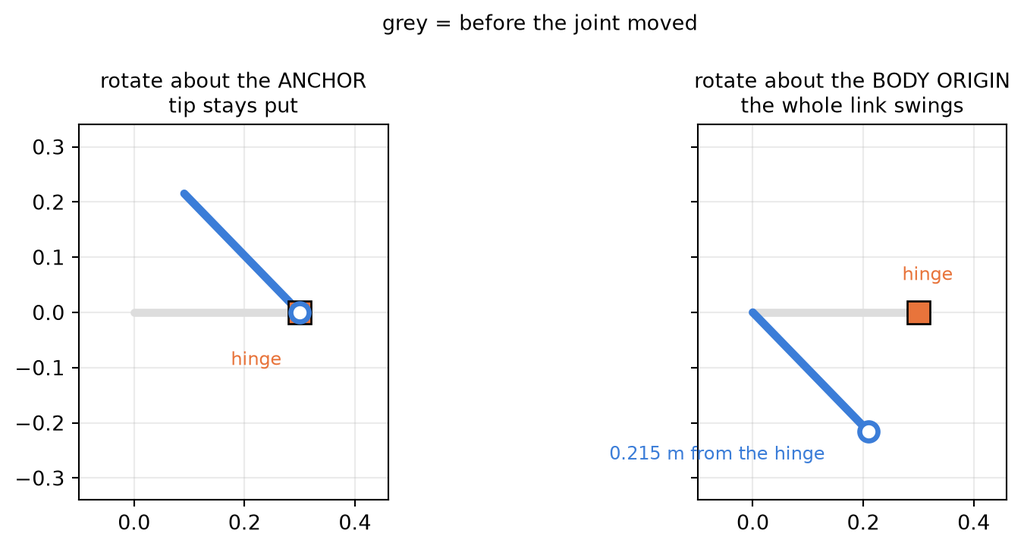

The site sits **on** the axis, so turning the joint must not move it at all. Drop the anchor and the link pivots about the wrong point, carrying the tip 21 cm away. Keep the term: it costs nothing on the G1, and it is the difference between right and wrong on a robot you write yourself.

## The workspace

You now have a function from angles to position. Call it three thousand times with random *legal* angles and you get the set of places the foot **can** be:

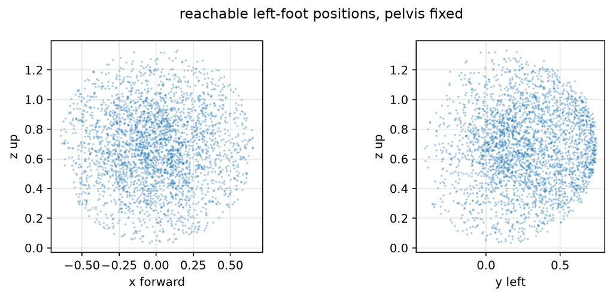

## Reading the workspace

The cloud is **not** a ball, and its shape is telling you about the robot:

Two consequences that matter later:

- A foot target near the boundary is reachable by essentially **one** posture, so no freedom is left over for balance or for avoiding an obstacle
- Near the boundary the leg is nearly **straight**, and there small foot motions demand enormous joint motions

That second point is the **singularity** that dominates next week — and it is why the Week 4 walker crouches instead of standing tall. The next two slides turn it into a number.

## The Jacobian, in millimetres

Forget the name for a moment and ask a concrete question: **if I nudge one joint by half a degree, how far does the foot move?** Measure it by simply doing it — this is a *derivative* being taken by hand, and the next slide names it:

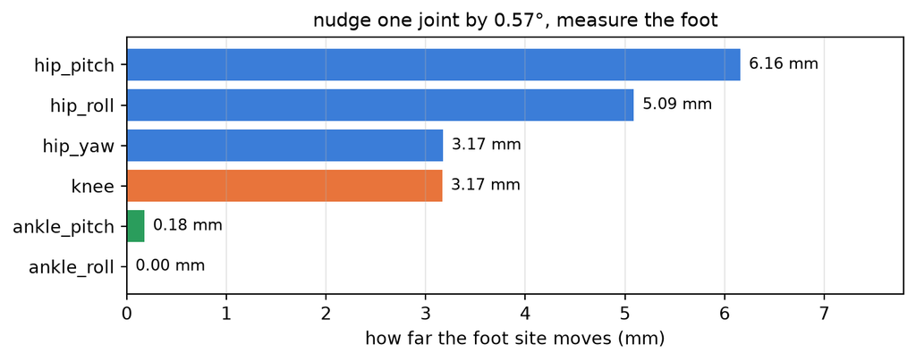

Six joints, six different sensitivities. The hip is the big lever; the ankle barely matters. And `ankle_roll` moves the foot **0.00 mm** — the foot site sits exactly on that axis, so rolling it changes the foot’s *orientation* and not its position at all.

## Divide by the nudge, and it is a derivative

Forward kinematics is a function $\mathbf{x} = f(\mathbf{q})$ — six angles in, three coordinates out. Its derivative is a $3\times 6$ matrix:

$$J \;=\; \frac{\partial \mathbf{x}}{\partial \mathbf{q}},
\qquad J_{ij} = \frac{\partial x_i}{\partial q_j}$$

We already measured the numerator. **Dividing by the nudge** turns millimetres into a slope, and the $j$-th column is exactly what we computed:

$$J\,\mathbf{e}_j \;\approx\; \frac{f(\mathbf{q} + \varepsilon\,\mathbf{e}_j) - f(\mathbf{q})}{\varepsilon}$$

where $\mathbf{e}_j$ is 1 in slot $j$ and 0 elsewhere — “move only joint $j$”.

```
finite differences, eps = 1e-6   (units: metres per radian)
    [-0.6156 -0.001  -0.0018 -0.2994 -0.0176  0.    ]
    [ 0.      0.509  -0.3173  0.      0.      0.    ]
    [-0.0125  0.0018 -0.001   0.1029  0.      0.    ]

MuJoCo's analytic mj_jacSite:
    [-0.6156 -0.001  -0.0018 -0.2994 -0.0176  0.    ]
    [ 0.      0.509  -0.3173  0.      0.      0.    ]
    [-0.0125  0.0018 -0.001   0.1029  0.      0.    ]

max difference: 3.08e-07
```

Row = which coordinate of the foot. Column = which joint. Entry $J_{ij}$ = metres of $x_i$ per radian of $q_j$. **The whole matrix is six of our nudges, divided.**

## How small should the nudge be?

Instinct says “as small as possible”. Instinct is wrong, and this is worth seeing once:

$$\text{error} \;\approx\; \underbrace{C\,\varepsilon}_{\text{truncation}} \;+\; \underbrace{u/\varepsilon}_{\text{round-off}}
\qquad\Longrightarrow\qquad \varepsilon_{\text{best}} \approx \sqrt{u} \approx 1.5\times10^{-8}$$

$u \approx 2.2\times10^{-16}$ is double precision. Too big and the straight line misses the curve; too small and $f(\mathbf{q}+\varepsilon) - f(\mathbf{q})$ is two nearly-equal numbers subtracted, so the digits that mattered cancel away.

```
       eps    max error vs analytic
     1e-01                3.077e-02
     1e-02                3.078e-03
     1e-03                3.078e-04
     1e-04                3.078e-05
     1e-06                3.078e-07
     1e-08                1.111e-08
     1e-10                1.564e-06
     1e-12                6.612e-05

sqrt(machine epsilon) = 1.49e-08
```

The best answer is about $10^{-8}$, right where $\sqrt{u}$ predicted. And this is why we use `mj_jacSite` in real code: **MuJoCo differentiates the chain analytically**, so there is no $\varepsilon$ to choose and no error to trade.

## Each column is a direction the foot can move

A column of $J$ is a **velocity**, not a place: turn joint $j$ at 1 rad/s and the foot sets off along that vector, at that speed. So draw the six columns from a common origin, to scale, seen from the side and from above:

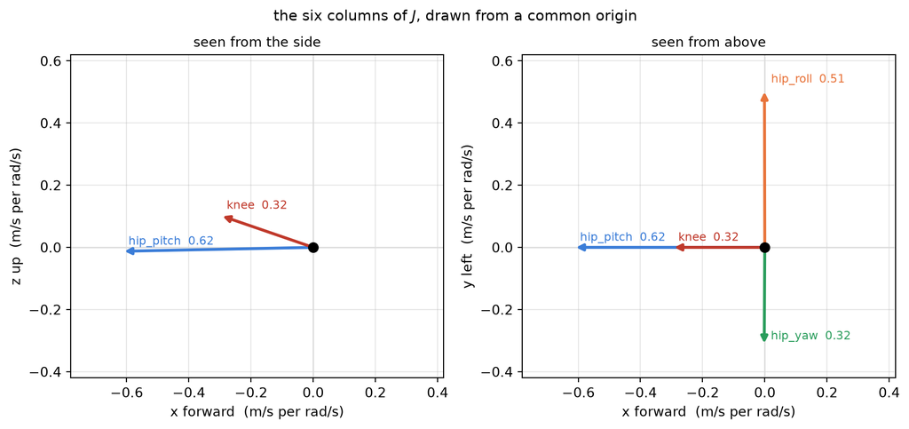

`hip_pitch` is the long arrow — it drives the foot backwards hardest. `knee` points backwards *and up*. `hip_roll` and `hip_yaw` barely show from the side and dominate from above: they move the foot **sideways**.

**Both ankle joints are missing**, for two different reasons. `ankle_pitch` is a 0.02 m/rad stub, too short to draw at this scale — the 0.18 mm bar. `ankle_roll` is exactly zero: that column has nothing in it, so there is literally nothing to draw.

Next week’s question is this picture read backwards: given a direction you *want* the foot to go, **which combination of these six arrows produces it?**

## The other three rows, and what $J$ is for

A foot pose is six numbers, not three, so the full Jacobian stacks **three more rows** for orientation — `mj_jacSite` fills both at once. Read as a rate, it says how fast the foot moves for a given joint speed:

$$\dot{\mathbf{x}} = J(\mathbf{q})\,\dot{\mathbf{q}}$$

```
  full leg Jacobian  : (6, 6)   (3 position + 3 orientation) x 6 joints
  singular values    : [1.8191 1.4818 1.0002 0.4045 0.4033 0.0887]
  largest / smallest : 1.8191 / 0.08867  =  condition number 20.5
```

A **square** Jacobian: six joints for six freedoms, which is why the foot can be put anywhere in any orientation. The singular values say how strongly the foot responds along six independent directions — the largest is the easiest direction to move, the smallest the hardest.

**When the smallest approaches zero, one direction has stopped responding.** That is a *singularity*, and next week it is the whole story: at the `stand` keyframe this number collapses to $9\times10^{-6}$, and inverting $J$ there is division by almost nothing.

## Exercises

**Warm-up — do these first**

1. **Predict, then check.** Using the formula on the paper slide, work out by hand where `paper_fk(0.0, 1.0, 0.0)` puts the foot. Then run it. Were the signs what you expected?
2. **Find the straight leg.** Call `paper_fk(0, 0, 0)` and compute the distance from hip to foot. Compare it with $L_1 + L_2 + \text{foot drop}$. Why do they agree, and what would break that agreement?
3. **Order, again.** Rotate $(1,0,0)$ by $30°$ about $z$ then $30°$ about $x$, and then in the other order. How far apart are the two answers?

**Main**

4. **Scalar-last.** Change `quat2mat` to read the quaternion as $(x,y,z,w)$ and re-run the check. Does the foot land somewhere plausible? That plausibility is exactly what makes this bug nasty.
5. **Break the anchor, properly.** Deleting `(a - Rj @ a)` changes nothing on the G1. Edit the toy MJCF so the hinge sits at `pos="0.15 0 0"` — the middle of the link — and predict the error *before* you run it.
6. **Orientation too.** Extend `my_fk` to return the foot’s rotation matrix as well, and check it against `site_xmat`. You should again reach $10^{-16}$.
7. **Both legs.** Compute the vector from the left foot to the right foot **in the pelvis frame**. Verify it is symmetric at the `stand` pose, and say what its length means physically.

**Harder**

8. **Straight-leg check.** Compute the Jacobian’s smallest singular value at the `stand` keyframe and at the crouch. Which is closer to singular, and by what factor? (The answer is larger than you will guess.)
9. **Workspace volume.** Estimate the reachable volume by Monte Carlo. Then ask how much of it survives the requirement that the foot stay **flat** — hint: look at `R[2,2]` of the foot’s rotation matrix.

## Lab class: on your laptop

```bash
uv run weeks/02-transforms/lab_viewer.py
```

Each pose of `POSES` (SPACE for the next); **green** sphere at MuJoCo’s foot site, **red** at the file’s own forward kinematics. **Both FKs are complete and explained** — `chain_fk` (six bodies, 1.8e-16) and `paper_fk` (three angles, 2.2e-06) — and `F` switches them. Nothing is simulated.

| Step | Do | Right looks like |
| --- | --- | --- |
| 1 | add three poses | the foot goes where you predicted; one pose explained from `fk.py` |
| 2 | ENTER on the crouch, then `F` | 1.8e-16, then 2.2e-06, both inside the green sphere |
| 3 | third pose, `F` | the red sphere leaves the foot by 1.2 mm: a planar model cannot know |
| 4 | break `chain_fk` | swap offset and rotation: it moves; drop `(a − Rj a)`: nothing, and why |
| 5 | foot 10 cm forward, still flat | pitch angles summing to zero; then deck `02b`, the lab class’s own |

## Lab class: `fk.py`, the chain one body at a time

```bash
uv run weeks/02-transforms/fk.py --angles -0.35 0 0 0.70 -0.35 0
```

Places the leg, walks pelvis → six bodies → foot site by hand, and prints a line per body: the offset from its parent, the joint, the angle, and where that leaves us. Then the paper model beside it, then the pose in the simulator.

```
body                      offset from parent (m)  joint          angle   world position after
pelvis                                                                   [0.     0.     0.79 ]
left_hip_pitch_link        [0.0, 0.0645, -0.1027] hip_pitch_joint -0.350  [0.     0.0645 0.6873]
left_hip_roll_link          [0.0, 0.052, -0.0305] hip_roll_joint   0.000  [0.0104 0.1165 0.6587]
left_hip_yaw_link           [0.025, 0.0, -0.1241] hip_yaw_joint    0.000  [0.0943 0.1165 0.5638]
left_knee_link         [-0.0783, 0.0021, -0.1773] knee_joint       0.700  [0.1154 0.1186 0.3711]
left_ankle_pitch_link        [0.0, -0.0001, -0.3] ankle_pitch_joint -0.350 [0.0125 0.1185 0.0893]
left_ankle_roll_link          [0.0, 0.0, -0.0176] ankle_roll_joint  0.000  [0.0125 0.1185 0.0717]
chain by hand : [0.012543 0.118506 0.071731]   max error vs MuJoCo 1.8e-16 m
paper (x, z)  : [0.012545 0.118506 0.071732]   max error vs MuJoCo 2.2e-06 m
```

Calls, in order: `leg_qpos_indices`, `mj_forward`, `leg_chain`, `body_pos`, `body_quat`, `jnt_axis`, `mju_quat2Mat`, `mju_axisAngle2Quat`, `site_pos`, `site_xpos`; then `launch_viewer(passive=True)` with two `user_scn` spheres.

## What you built today, in order

Two things, and **one depends on the other**. Keep the arrow pointing the right way:

$$\underbrace{\mathbf{x} = f(\mathbf{q})}_{\text{forward kinematics}}
\;\xrightarrow{\ \text{differentiate}\ }\;
\underbrace{J = \dfrac{\partial f}{\partial \mathbf{q}}}_{\text{the Jacobian}}$$

**1. Forward kinematics computes positions.** Walk the tree from the pelvis down, and at each link apply the fixed offset and the joint rotation, $\mathbf{p} \mapsto R\mathbf{p} + \mathbf{t}$, always relative to the parent. That is the *only* thing in this course that produces a position. Twelve lines, and it matched MuJoCo to $10^{-16}$.

**2. The Jacobian computes *change*, not position.** It is the derivative of step 1 — it answers “if the joints move a little, where does the foot go?” It cannot tell you where the foot *is*, and it never could: differentiating throws that away.

And the dependency runs one way only:

```
forward-kinematics evaluations needed to build J by hand: 7
   1 for the starting position, then 1 per joint

so: FK is the primitive. J is measured FROM it, never the reverse.
```

Even the “empirical” Jacobian is **seven calls to forward kinematics**. MuJoCo’s analytic version differentiates the same chain symbolically — faster, and with no $\varepsilon$ — but it is still $f$ that is being differentiated.

## Next week

**Inverse kinematics.** Today: angles in, position out. Next week: *position in, angles out* — which is harder, sometimes has many answers, sometimes none, and occasionally blows up entirely.

That is where the Jacobian earns its keep. You cannot invert $f$ directly, but you *can* ask $J$ which way to nudge the joints, take a small step, and repeat.

We start by inverting the very two-link leg you built on paper today, with the same $L_1$ and $L_2$ — and then throw it away for a method that handles all six joints at once.